### boosting in ensembles using the caret package

[output not shown]

Bagging(Bootstrap aggregating) 和 Boosting 是2種很受歡迎的 [ensemble](http://www.kdnuggets.com/2016/11/data-science-basics-intro-ensemble-learners.html) 技術，在上一次的分類學習方法中，Random Forest 和 C5.0 便是屬於 ensemble modeling，簡單來說，這2種技術運用一種演算法來建立一組models，最後用投票方式產出預測的結果，例如 Random Forest 用 bootstrap 的抽樣手法建立一組 decision trees 的 models，平均其結果做為預測值。Boosting 也是運用隨機抽樣和投票的手法，不過在建立 models 時會參照互補，根據上一回結果進行調整，並加入了權重的概念，因此它能增強 [weak learners](https://discuss.analyticsvidhya.com/t/what-is-the-fundamental-difference-between-randomforest-and-gradient-boosting-algorithms/2341/2)。GBM 和 XGBoost 是基於 Boosting 的2種技術，在精確率表現上相當卓越(但 overfitting 也常被批評)，頗受資料科學家喜愛，caret 套件對它的支援和整合也不錯，這次就來瞧一瞧它的魅力，使用的資料和策略方法跟前次相同…

#### **GBM (Gradient Boosted Machine)**

GBM (Gradient Boosted Machine) method 對應值為 gbm，預設值的最佳解 Kappa = 0.8733176，所使用的參數為 n.trees = 50, interaction.depth = 2, shrinkage = 0.1, n.minobsinnode = 10

```r
set.seed(777)
model.GBM <- train(Groups ~ ., data = whisky.feature, metric = "Kappa", trControl = ctrl,
                   method = "gbm")
getBest(model.GBM))
```

|  | shrinkage | interaction.depth | n.minobsinnode | n.trees | Accuracy | Kappa | AccuracySD | KappaSD |
| --- | --- | --- | --- | --- | --- | --- | --- | --- |
| 4 | 0.1 | 2 | 10 | 50 | 0.9287778 | 0.8733176 | 0.0814832 | 0.143993 |

gbm 提供4個 tuning 參數：

1. n.trees 是 Boosting 迭代的次數
2. interaction.depth 是變數交互作用最大深度，例如: 1 表示添加模式、2 表示雙向互動…
3. shrinkage 是應用在每棵樹擴展時收縮參數(每棵樹的學習速率)
4. n.minobsinnode 是樹節點中的最小觀測數

```r
# Get Parameter
getModelInfo(model = "gbm")$gbm$parameters
```

```
##           parameter   class                   label
## 1           n.trees numeric   # Boosting Iterations
## 2 interaction.depth numeric          Max Tree Depth
## 3         shrinkage numeric               Shrinkage
## 4    n.minobsinnode numeric Min. Terminal Node Size
```

手動設定 tuning 參數，n.trees 設定 50 ~ 500，間隔 50 ，interaction.depth 設定最大深度 1 ~ 3，學習速率 shrinkage 設定 0.1, 0.2, 0.3，n.minobsinnode 維持預設的 10

```r
set.seed(777)
# Tuning Grids
grid.GBM <- expand.grid(
    n.trees = seq(50, 500, by = 50),
    interaction.depth = c(1:3),
    shrinkage = seq(0.1, 0.3, by = 0.1),
    n.minobsinnode = 10
  )
model.GBM <- train(Groups ~ ., data = whisky.feature, metric = "Kappa", trControl = ctrl,
                   tuneGrid = grid.GBM, method = "gbm")
getBest(model.GBM)
```

經過 tuning process，這次得到的最佳 Kappa 值為0.8908807 (大於之前的0.8733176)，使用的參數設定 n.trees = 500, interaction.depth = 3, shrinkage = 0.3, n.minobsinnode = 10。從下圖可看出變數交互作用最大深度(Max Tree Depth)為 1 時表現普遍不佳，學習速率 0.3 在最大迭代值 500 時 Kappa 最大…後續再 tuning 增加學習速率或迭代值或許能得到更佳的解

|  | shrinkage | interaction.depth | n.minobsinnode | n.trees | Accuracy | Kappa | AccuracySD | KappaSD |
| --- | --- | --- | --- | --- | --- | --- | --- | --- |
| 90 | 0.3 | 3 | 10 | 500 | 0.9396667 | 0.8908807 | 0.0790251 | 0.1492872 |

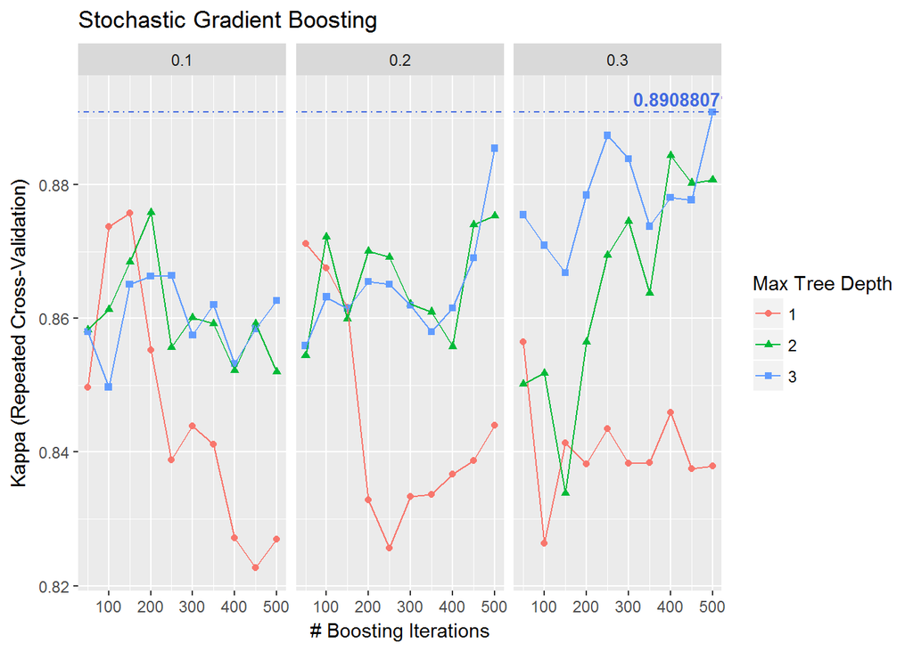

此外，caret 套件提供 varImp 方法，能計算出 model 中變數的重要性(variable importance)

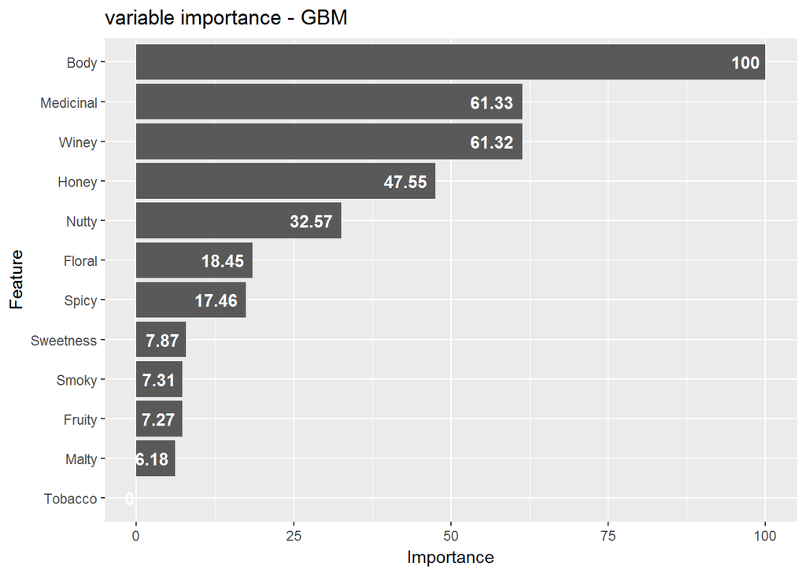

```r
varImp(model.GBM)
```

#### **XGBoost (eXtreme Gradient Boosting)**

XGBoost 的 method 對應值為 xgbTree，預設值的最佳解 Kappa = 0.9200535，表現的相當不錯，使用的參數為 nrounds = 50, max_depth = 1, eta = 0.3, gamma = 0, colsample_bytree = 0.8, min_child_weight = 1

```r
set.seed(777)
model.XGBoost <- train(Groups ~ ., data = whisky.feature, metric = "Kappa", trControl = ctrl,
                   method = "xgbTree")
getBest(model.XGBoost))
```

|  | eta | max_depth | gamma | colsample_bytree | min_child_weight | nrounds | Accuracy | Kappa | AccuracySD | KappaSD |
| --- | --- | --- | --- | --- | --- | --- | --- | --- | --- | --- |
| 4 | 0.3 | 1 | 0 | 0.8 | 1 | 50 | 0.9566667 | 0.9200535 | 0.068194 | 0.127985 |

xgbTree 提供6個 tuning 參數：

1. nrounds 是最大迭代值
2. max_depth 為樹的最大深度，增加此值將使模型更複雜、可能 overfitting
3. eta 是控制學習速率的參數(0 ~ 1)，用來防止 overfitting，一般學習速率小、迭代值會設較大
4. gamma 是需要進一步分割時減少損失最小值，值若越大代表算法越保守
5. colsample_bytree 參數(0 ~ 1)決定每棵樹隨選特徵最大值
6. min_child_weight 是實例權重和的最小值，若小於該值則停止分割動作，值若越大代表算法越保守

```r
# Get Parameter
getModelInfo(model = "xgbTree")$xgbTree$parameters
```

```
##          parameter   class                          label
## 1          nrounds numeric          # Boosting Iterations
## 2        max_depth numeric                 Max Tree Depth
## 3              eta numeric                      Shrinkage
## 4            gamma numeric         Minimum Loss Reduction
## 5 colsample_bytree numeric     Subsample Ratio of Columns
## 6 min_child_weight numeric Minimum Sum of Instance Weight
```

手動設定 tuning 參數，nrounds 設定 50 ~ 500，間隔 50 ，max_depth 設定最大深度 1 ~ 3，學習速率 eta 設定 0.1, 0.2, 0.3，gamma 維持預設的 0，colsample_bytree 設 0.8，min_child_weight 維持預設的 1

```r
set.seed(777)
# Tuning Grids
grid.XGBoost <- expand.grid(
  nrounds = seq(50, 500, by = 50),
  max_depth = c(1:3),
  eta = seq(0.1, 0.3, by = 0.1),
  gamma = 0,
  colsample_bytree = 0.8,
  min_child_weight = 1
)
model.XGBoost <- train(Groups ~ ., data = whisky.feature, metric = "Kappa", trControl = ctrl,
                   tuneGrid = grid.XGBoost, method = "xgbTree")
getBest(model.XGBoost)
```

經過 tuning process，這次得到的最佳 Kappa 值為 0.9224663 (比之前的 0.9200535 更佳)，使用的參數設定 nrounds = 300, min_child_weight = 1, colsample_bytree = 0.8, gamma = 0, max_depth = 1, eta = 0.1

|  | eta | max_depth | gamma | colsample_bytree | min_child_weight | nrounds | Accuracy | Kappa | AccuracySD | KappaSD |
| --- | --- | --- | --- | --- | --- | --- | --- | --- | --- | --- |
| 6 | 0.1 | 1 | 0 | 0.8 | 1 | 300 | 0.9568889 | 0.9224663 | 0.0641735 | 0.1168371 |

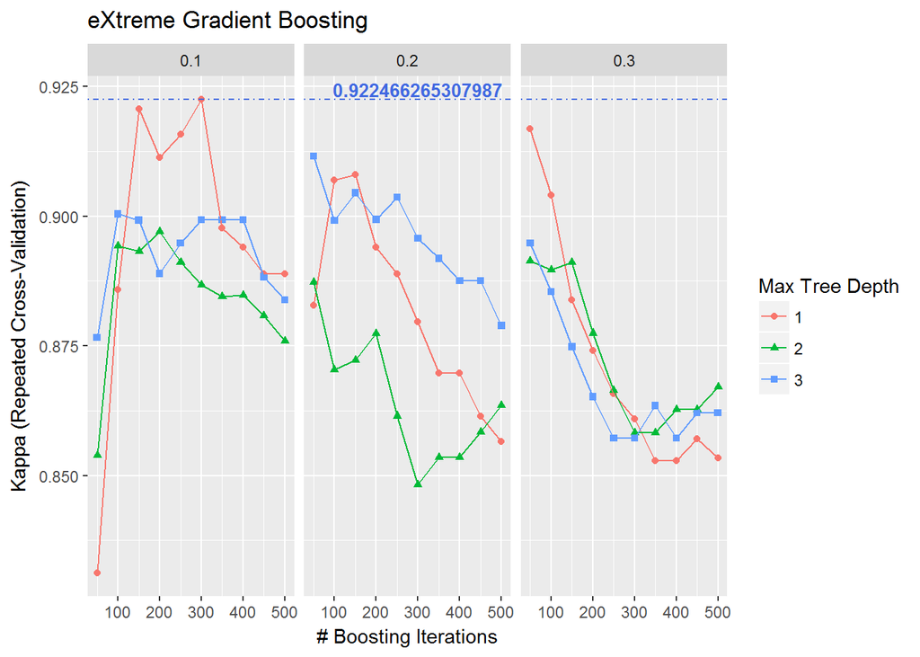

計算變數重要性(variable importance)，可看出順序比重和 GBM 有所不同

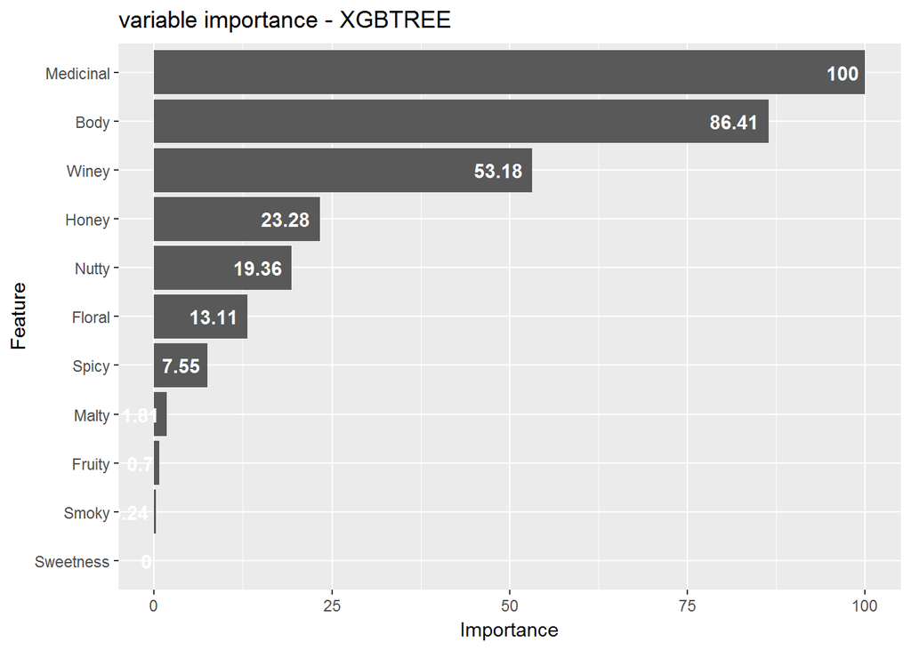

```r
varImp(model.XGBoost)
```

#### **Performance Differences**

XGBoost 是 GBM 的改良版本，從這次結果看來不管是 Accuracy 或 Kappa 表現上都比 GBM 來的好，也超越了上次6種分類方法，表示它的對應權重及錯誤修正機制的確能讓 weak learners 變強，或許這也是它廣受歡迎之處

|  | Min. | 1st Qu. | Median | Mean | 3rd Qu. | Max. | NA’s |
| --- | --- | --- | --- | --- | --- | --- | --- |
| GBM | 0.6667 | 0.8889 | 1 | 0.9397 | 1 | 1 | 0 |
| XGBoost | 0.7778 | 0.8889 | 1 | 0.9569 | 1 | 1 | 0 |

|  | Min. | 1st Qu. | Median | Mean | 3rd Qu. | Max. | NA’s |
| --- | --- | --- | --- | --- | --- | --- | --- |
| GBM | 0.2895 | 0.7867 | 1 | 0.8909 | 1 | 1 | 0 |
| XGBoost | 0.5714 | 0.8200 | 1 | 0.9225 | 1 | 1 | 0 |

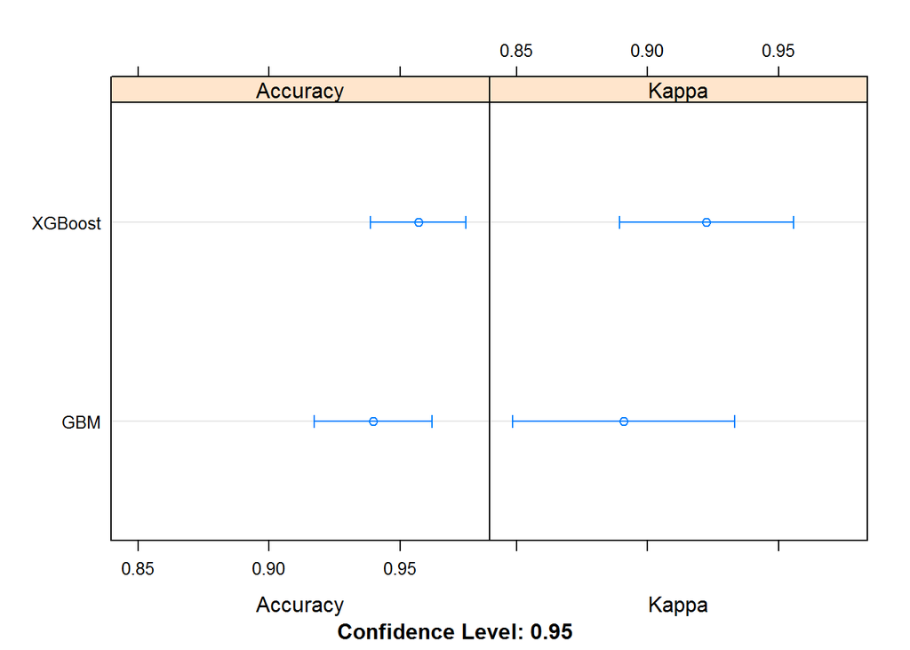

### Lessons Learned:

#### Ensemble Learning Techniques

#### GBM (Gradient Boosted Machine)

#### XGBoost (eXtreme Gradient Boosting)